# EasyVisa Project

## Context:

Business communities in the United States are facing high demand for human resources, but one of the constant challenges is identifying and attracting the right talent, which is perhaps the most important element in remaining competitive. Companies in the United States look for hard-working, talented, and qualified individuals both locally as well as abroad.

The Immigration and Nationality Act (INA) of the US permits foreign workers to come to the United States to work on either a temporary or permanent basis. The act also protects US workers against adverse impacts on their wages or working conditions by ensuring US employers' compliance with statutory requirements when they hire foreign workers to fill workforce shortages. The immigration programs are administered by the Office of Foreign Labor Certification (OFLC).

OFLC processes job certification applications for employers seeking to bring foreign workers into the United States and grants certifications in those cases where employers can demonstrate that there are not sufficient US workers available to perform the work at wages that meet or exceed the wage paid for the occupation in the area of intended employment.

## Objective:

In FY 2016, the OFLC processed 775,979 employer applications for 1,699,957 positions for temporary and permanent labor certifications. This was a nine percent increase in the overall number of processed applications from the previous year. The process of reviewing every case is becoming a tedious task as the number of applicants is increasing every year.

The increasing number of applicants every year calls for a Machine Learning based solution that can help in shortlisting the candidates having higher chances of VISA approval. OFLC has hired your firm EasyVisa for data-driven solutions. You as a data scientist have to analyze the data provided and, with the help of a classification model:

- Facilitate the process of visa approvals.
- Recommend a suitable profile for the applicants for whom the visa should be certified or denied based on the drivers that significantly influence the case status.

## Data Description

The data contains the different attributes of the employee and the employer. The detailed data dictionary is given below.

- case_id: ID of each visa application
- continent: Information of continent the employee
- education_of_employee: Information of education of the employee
- has_job_experience: Does the employee has any job experience? Y= Yes; N = No
- requires_job_training: Does the employee require any job training? Y = Yes; N = No
- no_of_employees: Number of employees in the employer's company
- yr_of_estab: Year in which the employer's company was established
- region_of_employment: Information of foreign worker's intended region of employment in the US.
- prevailing_wage: Average wage paid to similarly employed workers in a specific occupation in the area of intended employment. The purpose of the prevailing wage is to ensure that the foreign worker is not underpaid compared to other workers offering the same or similar service in the same area of employment.
- unit_of_wage: Unit of prevailing wage. Values include Hourly, Weekly, Monthly, and Yearly.
- full_time_position: Is the position of work full-time? Y = Full Time Position; N = Part Time Position
- case_status: Flag indicating if the Visa was certified or denied

## Importing necessary libraries and data

```python
# this will help in making the Python code more structured automatically (good coding practice)
%load_ext nb_black

# Library to suppress warnings or deprecation notes
import warnings

warnings.filterwarnings("ignore")

# Libraries to help with reading and manipulating data
import numpy as np
import pandas as pd

# Libraries to help with data visualization
import matplotlib.pyplot as plt

%matplotlib inline
import seaborn as sns

# Libraries to split data, impute missing values
from sklearn.model_selection import train_test_split
from sklearn.impute import SimpleImputer

# Libraries to import decision tree classifier and different ensemble classifiers
from sklearn.ensemble import BaggingClassifier
from sklearn.ensemble import RandomForestClassifier
from sklearn.tree import DecisionTreeClassifier
from sklearn import tree
from sklearn.ensemble import AdaBoostClassifier, GradientBoostingClassifier

# To install xgboost library use - !pip install xgboost
from xgboost import XGBClassifier
from sklearn.ensemble import StackingClassifier

# Libtune to tune model, get different metric scores
from sklearn import metrics
from sklearn.metrics import (
    confusion_matrix,
    classification_report,
    accuracy_score,
    precision_score,
    recall_score,
    f1_score,
    roc_auc_score,
)
import scipy.stats as stats
from sklearn.model_selection import GridSearchCV

from sklearn.tree import DecisionTreeRegressor
from sklearn.ensemble import (
    BaggingRegressor,
    RandomForestRegressor,
    GradientBoostingRegressor,
    AdaBoostRegressor,
    StackingRegressor,
)
from xgboost import XGBRegressor
```

### Read the dataset

```python
visa = pd.read_csv("EasyVisa.csv")
```

```python
# copying data to another varaible to avoid any changes to original data
data = visa.copy()
```

## Data Overview

### View the first and last 5 rows of the dataset.

```python
data.head()
```

|  | case_id | continent | education_of_employee | has_job_experience | requires_job_training | no_of_employees | yr_of_estab | region_of_employment | prevailing_wage | unit_of_wage | full_time_position | case_status |
| --- | --- | --- | --- | --- | --- | --- | --- | --- | --- | --- | --- | --- |
| 0 | EZYV01 | Asia | High School | N | N | 14513 | 2007 | West | 592.2029 | Hour | Y | Denied |
| 1 | EZYV02 | Asia | Master's | Y | N | 2412 | 2002 | Northeast | 83425.6500 | Year | Y | Certified |
| 2 | EZYV03 | Asia | Bachelor's | N | Y | 44444 | 2008 | West | 122996.8600 | Year | Y | Denied |
| 3 | EZYV04 | Asia | Bachelor's | N | N | 98 | 1897 | West | 83434.0300 | Year | Y | Denied |
| 4 | EZYV05 | Africa | Master's | Y | N | 1082 | 2005 | South | 149907.3900 | Year | Y | Certified |

```python
data.tail()
```

|  | case_id | continent | education_of_employee | has_job_experience | requires_job_training | no_of_employees | yr_of_estab | region_of_employment | prevailing_wage | unit_of_wage | full_time_position | case_status |
| --- | --- | --- | --- | --- | --- | --- | --- | --- | --- | --- | --- | --- |
| 25475 | EZYV25476 | Asia | Bachelor's | Y | Y | 2601 | 2008 | South | 77092.57 | Year | Y | Certified |
| 25476 | EZYV25477 | Asia | High School | Y | N | 3274 | 2006 | Northeast | 279174.79 | Year | Y | Certified |
| 25477 | EZYV25478 | Asia | Master's | Y | N | 1121 | 1910 | South | 146298.85 | Year | N | Certified |
| 25478 | EZYV25479 | Asia | Master's | Y | Y | 1918 | 1887 | West | 86154.77 | Year | Y | Certified |
| 25479 | EZYV25480 | Asia | Bachelor's | Y | N | 3195 | 1960 | Midwest | 70876.91 | Year | Y | Certified |

### Understand the shape of the dataset.

```python
data.shape
```

```
(25480, 12)
```

- There are 25480 observations and 12 columns in the dataset

### Check the data types of the columns for the dataset.

```python
data.info()
```

```
<class 'pandas.core.frame.DataFrame'>
RangeIndex: 25480 entries, 0 to 25479
Data columns (total 12 columns):
 #   Column                 Non-Null Count  Dtype
---  ------                 --------------  -----
 0   case_id                25480 non-null  object
 1   continent              25480 non-null  object
 2   education_of_employee  25480 non-null  object
 3   has_job_experience     25480 non-null  object
 4   requires_job_training  25480 non-null  object
 5   no_of_employees        25480 non-null  int64
 6   yr_of_estab            25480 non-null  int64
 7   region_of_employment   25480 non-null  object
 8   prevailing_wage        25480 non-null  float64
 9   unit_of_wage           25480 non-null  object
 10  full_time_position     25480 non-null  object
 11  case_status            25480 non-null  object
dtypes: float64(1), int64(2), object(9)
memory usage: 2.3+ MB
```

**Observations -**

- Most of the data-types are object, this means we need to convert these into suitable data-type before we feed our data into the model.
- Two columns no_of_employees and yr_of_estab are of int64 data-types and one of the columns prevailing_wage has data-type float64.
- There are no null values in the dataset

## Data Preprocessing

### Let's check the duplicate data. And if any, we should remove it.

```python
data[data.duplicated()].count()
```

```
case_id                  0
continent                0
education_of_employee    0
has_job_experience       0
requires_job_training    0
no_of_employees          0
yr_of_estab              0
region_of_employment     0
prevailing_wage          0
unit_of_wage             0
full_time_position       0
case_status              0
dtype: int64
```

- There are no duplicate values in the dataset.

### Check for missing values

```python
data.isnull().sum()
```

```
case_id                  0
continent                0
education_of_employee    0
has_job_experience       0
requires_job_training    0
no_of_employees          0
yr_of_estab              0
region_of_employment     0
prevailing_wage          0
unit_of_wage             0
full_time_position       0
case_status              0
dtype: int64
```

- There are no missing values in the dataset.

### Fixing the datatypes

```python
# converting "objects" to "category" reduces the data space required to store the dataframe
cols = data.select_dtypes(["object"])
cols.columns
```

```
Index(['case_id', 'continent', 'education_of_employee', 'has_job_experience',
       'requires_job_training', 'region_of_employment', 'unit_of_wage',
       'full_time_position', 'case_status'],
      dtype='object')
```

```python
for i in cols.columns:
    data[i] = data[i].astype("category")
```

```python
data.info()
```

```
<class 'pandas.core.frame.DataFrame'>
RangeIndex: 25480 entries, 0 to 25479
Data columns (total 12 columns):
 #   Column                 Non-Null Count  Dtype
---  ------                 --------------  -----
 0   case_id                25480 non-null  category
 1   continent              25480 non-null  category
 2   education_of_employee  25480 non-null  category
 3   has_job_experience     25480 non-null  category
 4   requires_job_training  25480 non-null  category
 5   no_of_employees        25480 non-null  int64
 6   yr_of_estab            25480 non-null  int64
 7   region_of_employment   25480 non-null  category
 8   prevailing_wage        25480 non-null  float64
 9   unit_of_wage           25480 non-null  category
 10  full_time_position     25480 non-null  category
 11  case_status            25480 non-null  category
dtypes: category(9), float64(1), int64(2)
memory usage: 2.0 MB
```

- we can see that the memory usage has decreased from 2.3 MB to 2 MB

### Summary of the dataset

```python
#Numerical variables
data.describe().T
```

|  | count | mean | std | min | 25% | 50% | 75% | max |
| --- | --- | --- | --- | --- | --- | --- | --- | --- |
| no_of_employees | 25480.0 | 5667.043210 | 22877.928848 | -26.0000 | 1022.00 | 2109.00 | 3504.0000 | 602069.00 |
| yr_of_estab | 25480.0 | 1979.409929 | 42.366929 | 1800.0000 | 1976.00 | 1997.00 | 2005.0000 | 2016.00 |
| prevailing_wage | 25480.0 | 74455.814592 | 52815.942327 | 2.1367 | 34015.48 | 70308.21 | 107735.5125 | 319210.27 |

**Observations**

- The min value of no_of_employees is -26 which seems to be a data entry error. The max value is 602069.It looks like there are many outliers to the right. The mean is 5667 and median is 2109.
- The yr_of_estab varies from 1800 to 2016. The mean is 1979 and median is 1997. Since mean is less than median data is skewed towards the left.
- prevailing_wage varies from 2.14 to 319210.Mean is 74455 and median is 70308. We need to check the units and put them in a single unit for easy processing.

```python
# Categorical Variables
data.describe(include=["category"]).T
```

|  | count | unique | top | freq |
| --- | --- | --- | --- | --- |
| case_id | 25480 | 25480 | EZYV01 | 1 |
| continent | 25480 | 6 | Asia | 16861 |
| education_of_employee | 25480 | 4 | Bachelor's | 10234 |
| has_job_experience | 25480 | 2 | Y | 14802 |
| requires_job_training | 25480 | 2 | N | 22525 |
| region_of_employment | 25480 | 5 | Northeast | 7195 |
| unit_of_wage | 25480 | 4 | Year | 22962 |
| full_time_position | 25480 | 2 | Y | 22773 |
| case_status | 25480 | 2 | Certified | 17018 |

### Let's look at the unqiue values of all the categories

```python
cat_columns = [
    "case_id",
    "continent",
    "education_of_employee",
    "has_job_experience",
    "requires_job_training",
    "region_of_employment",
    "unit_of_wage",
    "full_time_position",
    "case_status",
]
for i in cat_columns:
    print(data[i].value_counts())
    print("*" * 50)
```

```
EZYV01       1
EZYV25287    1
EZYV25285    1
EZYV25284    1
EZYV25283    1
            ..
EZYV17633    1
EZYV17632    1
EZYV17631    1
EZYV17630    1
EZYV9999     1
Name: case_id, Length: 25480, dtype: int64
Asia             16861
Europe            3732
North America     3292
South America      852
Africa             551
Oceania            192
Name: continent, dtype: int64
Bachelor's     10234
Master's        9634
High School     3420
Doctorate       2192
Name: education_of_employee, dtype: int64
Y    14802
N    10678
Name: has_job_experience, dtype: int64
N    22525
Y     2955
Name: requires_job_training, dtype: int64
Northeast    7195
South        7017
West         6586
Midwest      4307
Island        375
Name: region_of_employment, dtype: int64
Year     22962
Hour      2157
Week       272
Month       89
Name: unit_of_wage, dtype: int64
Y    22773
N     2707
Name: full_time_position, dtype: int64
Certified    17018
Denied        8462
Name: case_status, dtype: int64
```

**Observations**

### Dropping case_id column which is not adding any valuable information.

```python
data.drop(["case_id"], axis=1, inplace=True)
```

### Dropping rows with negative or zero no_of_employees

```python
len(data[data["no_of_employees"] <= 0])
```

```
33
```

```python
# drop these rows
data.drop(
    data[data["no_of_employees"] < 0].index, axis=0, inplace=True,
)
```

```python
data.shape
```

```
(25447, 11)
```

## Exploratory Data Analysis (EDA)

### Univariate analysis

**Let us explore the numerical variables first**

```python
# function to plot a boxplot and a histogram along the same scale.


def histogram_boxplot(data, feature, figsize=(12, 7), kde=False, bins=None):
    """
    Boxplot and histogram combined

    data: dataframe
    feature: dataframe column
    figsize: size of figure (default (12,7))
    kde: whether to show the density curve (default False)
    bins: number of bins for histogram (default None)
    """
    f2, (ax_box2, ax_hist2) = plt.subplots(
        nrows=2,  # Number of rows of the subplot grid= 2
        sharex=True,  # x-axis will be shared among all subplots
        gridspec_kw={"height_ratios": (0.25, 0.75)},
        figsize=figsize,
    )  # creating the 2 subplots
    sns.boxplot(
        data=data, x=feature, ax=ax_box2, showmeans=True, color="violet"
    )  # boxplot will be created and a star will indicate the mean value of the column
    sns.histplot(
        data=data, x=feature, kde=kde, ax=ax_hist2, bins=bins, palette="winter"
    ) if bins else sns.histplot(
        data=data, x=feature, kde=kde, ax=ax_hist2
    )  # For histogram
    ax_hist2.axvline(
        data[feature].mean(), color="green", linestyle="--"
    )  # Add mean to the histogram
    ax_hist2.axvline(
        data[feature].median(), color="black", linestyle="-"
    )  # Add median to the histogram
```

### Observations on no_of_employees

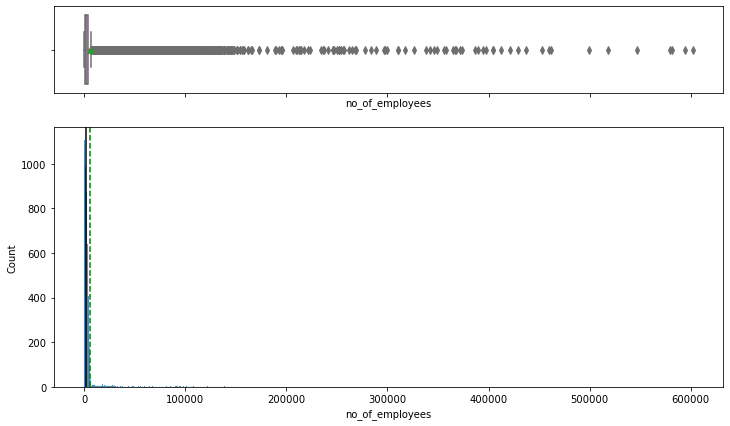

```python
histogram_boxplot(data, "no_of_employees")
```

**Observations**

- 75% of the number of employess are below 3505.
- There are huge number of outliers to the right, the max value being 602069.
- This data seems credible as there are companies with employees upto 602069.

### Observations on yr_of_estab

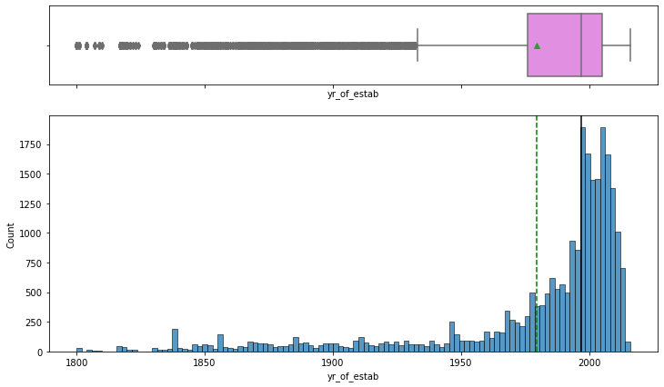

```python
histogram_boxplot(data, "yr_of_estab")
```

**Observations**

- The yr_of_estab varies from 1800 to 2016. The mean is 1979 and median is 1997.
- Since mean is less than median data is skewed towards the left.
- The data seems credible as there can be companies established as early as 1800s.
- More number of comapnies were established after 1970s.

### Observations on prevailing_wage

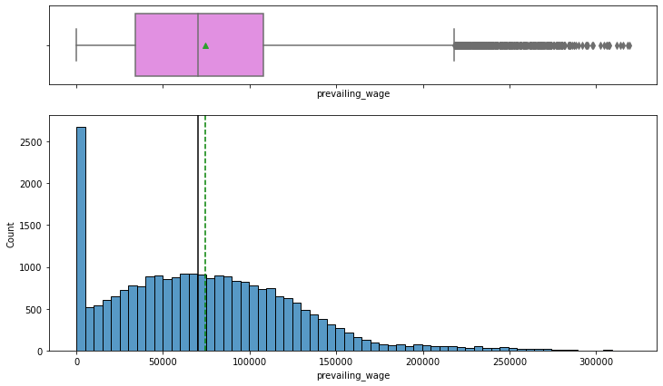

```python
histogram_boxplot(data, "prevailing_wage")
```

**Observations**

- prevailing_wage varies from 2.14 to 319210. Mean is 74455 and median is 70308.
- More number of prevailing_wages are on the lower side.
- We need to check the units and put them in a single unit for easy processing.

**Let us now explore the categorical variables**

```python
# function to create labeled barplots


def labeled_barplot(data, feature, perc=False, n=None):
    """
    Barplot with percentage at the top

    data: dataframe
    feature: dataframe column
    perc: whether to display percentages instead of count (default is False)
    n: displays the top n category levels (default is None, i.e., display all levels)
    """

    total = len(data[feature])  # length of the column
    count = data[feature].nunique()
    if n is None:
        plt.figure(figsize=(count + 1, 5))
    else:
        plt.figure(figsize=(n + 1, 5))

    plt.xticks(rotation=90, fontsize=15)
    ax = sns.countplot(
        data=data,
        x=feature,
        palette="Paired",
        order=data[feature].value_counts().index[:n].sort_values(),
    )

    for p in ax.patches:
        if perc == True:
            label = "{:.1f}%".format(
                100 * p.get_height() / total
            )  # percentage of each class of the category
        else:
            label = p.get_height()  # count of each level of the category

        x = p.get_x() + p.get_width() / 2  # width of the plot
        y = p.get_height()  # height of the plot

        ax.annotate(
            label,
            (x, y),
            ha="center",
            va="center",
            size=12,
            xytext=(0, 5),
            textcoords="offset points",
        )  # annotate the percentage

    plt.show()  # show the plot
```

### Observations on continent

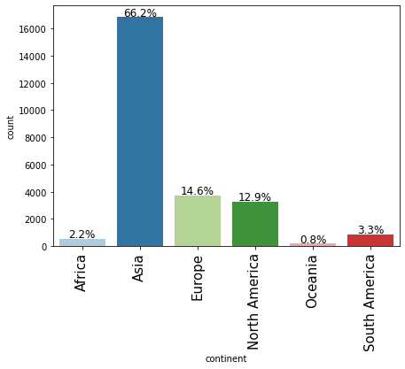

```python
labeled_barplot(data, "continent", perc=True)
```

**Observations**

- The highest percent 66.2% employees are from Asia.
- The least with 0.8% of employees are from Oceania.

### Observations on education_of_employee

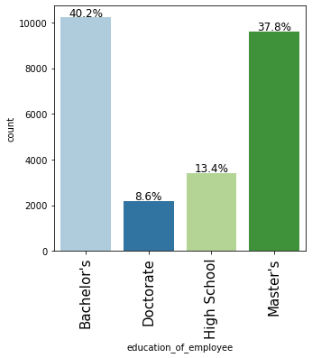

```python
labeled_barplot(data, "education_of_employee", perc=True)
```

**Observations**

- 40.2% of applicants have Bachelor's degree followed by 37.8% with Master's.
- 13.4% employees have High School degree and 8.6% have Doctorate.

### Observations on has_job_experience

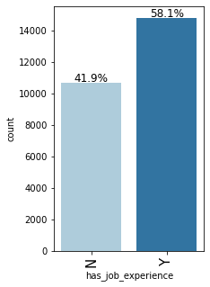

```python
labeled_barplot(data, "has_job_experience", perc=True)
```

**Observations**

- 58.1 % employess have job experience.
- 41.9 % employees do not have job experience

### Observations on requires_job_training

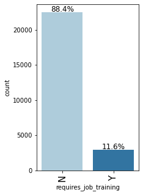

```python
labeled_barplot(data, "requires_job_training", perc=True)
```

**Observations**

### Observations on region_of_employment

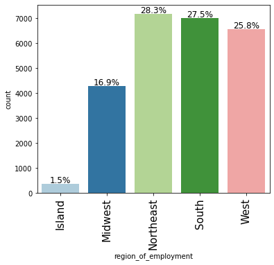

```python
labeled_barplot(data, "region_of_employment", perc=True)
```

**Observations**

- 28.3% emplyments are in the Northeast region of US.
- Only 1.5% emplyments are in the Island region of US.

### Observations on unit_of_wage

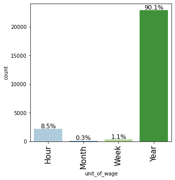

```python
labeled_barplot(data, "unit_of_wage", perc=True)
```

**Observations**

- 90.1% prevailing wages given are yearly wages.
- 0.3 % are monthly wages
- 8.5% are Hourly wages
- 1.1% are weekly wages.

### Observations on full_time_position

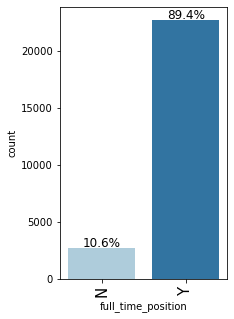

```python
labeled_barplot(data, "full_time_position", perc=True)
```

**Observations**

- 89.4% of the positions are full-time.
- Only 10.6% are not full-time positions.

### Observations on case_status

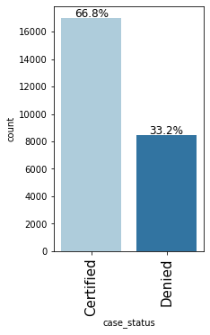

```python
labeled_barplot(data, "case_status", perc=True)
```

**Observations**

- 66.8% of employees are certified and given visa.
- 33.2% of employees are Denied visa.

## Bivariate Analysis

**Plot bivariate charts between numeric variables to understand their interaction with each other.**

### Correlation

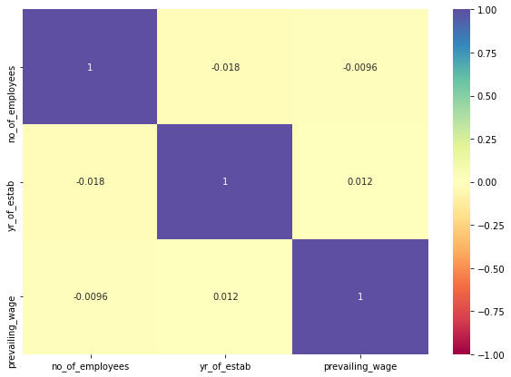

```python
plt.figure(figsize=(10, 7))
sns.heatmap(data.corr(), annot=True, vmin=-1, vmax=1, cmap="Spectral")
plt.show()
```

- There are no significant correlation between any of the Numerical variables.

### Observations on no_of_employees vs case_status

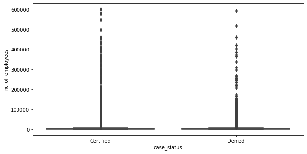

```python
plt.figure(figsize=(10, 5))
sns.boxplot(data=data, x="case_status", y="no_of_employees")
```

**Observations**

- We do not find any significant relation between case_status and no_of_employees.

### yr_of_estab vs case_status

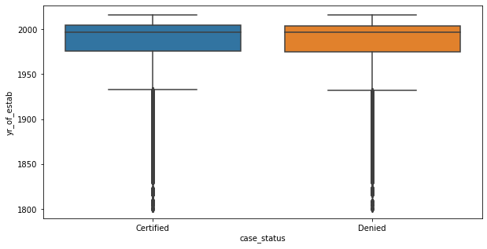

```python
plt.figure(figsize=(10, 5))
sns.boxplot(data=data, x="case_status", y="yr_of_estab")
```

**Observations**

- We do not find any significant relation between case_status and yr_of_estab.

### prevailing_wage vs case_status

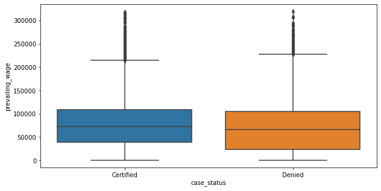

```python
plt.figure(figsize=(10, 5))
sns.boxplot(data=data, x="case_status", y="prevailing_wage")
```

**Observations**

- For prevailing_wage below 50000, The Denial cases are more compared to Certified cases.

```python
# function to plot stacked bar chart
def stacked_barplot(data, predictor, target):

    ax = pd.crosstab(data[predictor], data[target]).apply(
        lambda r: r / r.sum() * 100, axis=1
    )
    ax_1 = ax.plot.bar(figsize=(10, 5), stacked=True, rot=0)
    display(ax)

    plt.legend(loc="upper center", bbox_to_anchor=(0.1, 1.0), title=target)

    plt.xlabel(predictor)
    plt.ylabel("Percent Distribution")

    for rec in ax_1.patches:
        height = rec.get_height()
        ax_1.text(
            rec.get_x() + rec.get_width() / 2,
            rec.get_y() + height / 2,
            "{:.0f}%".format(height),
            ha="center",
            va="bottom",
        )


plt.show()
```

### continent vs case_status

| case_status continent | Certified | Denied |
| --- | --- | --- |
| Africa | 72.000000 | 28.000000 |
| Asia | 65.326603 | 34.673397 |
| Europe | 79.232627 | 20.767373 |
| North America | 61.971402 | 38.028598 |
| Oceania | 63.541667 | 36.458333 |
| South America | 57.814336 | 42.185664 |

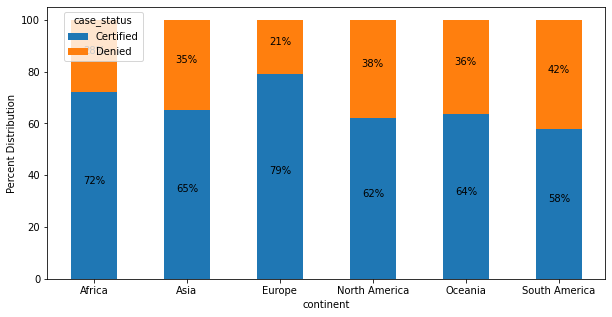

```python
stacked_barplot(data, "continent", "case_status")
```

**Observations**

- Employees from Europe have highest Certification with 79% cases.
- Employees from South America has the least Certification with 58% cases.

### education_of_employee vs case_status

| case_status education_of_employee | Certified | Denied |
| --- | --- | --- |
| Bachelor's | 62.250489 | 37.749511 |
| Doctorate | 87.254454 | 12.745546 |
| High School | 34.074941 | 65.925059 |
| Master's | 78.621908 | 21.378092 |

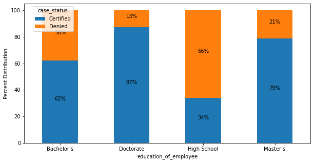

```python
stacked_barplot(data, "education_of_employee", "case_status")
```

**Observations**

- We can see that as the education increases there are higher chances of Visa Certification.
- Employees with Doctorate have 87% Certification cases.
- Employees with only High School Education have only 34% cases of Certification.

### has_job_experience vs case_status

| case_status has_job_experience | Certified | Denied |
| --- | --- | --- |
| N | 56.148579 | 43.851421 |
| Y | 74.496145 | 25.503855 |

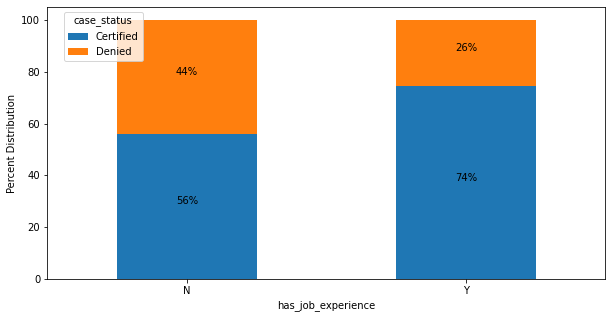

```python
stacked_barplot(data, "has_job_experience", "case_status")
```

**Observations**

- Job experience plays an important role in Visa Certification.
- 74% employees with job experience have Visa Certification compared to 56% employees with no job experience.

### requires_job_training vs case_status

| case_status requires_job_training | Certified | Denied |
| --- | --- | --- |
| N | 66.672593 | 33.327407 |
| Y | 67.853510 | 32.146490 |

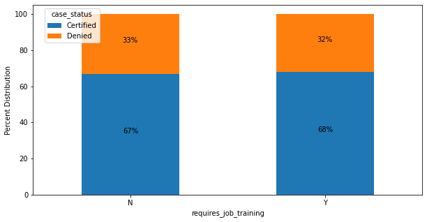

```python
stacked_barplot(data, "requires_job_training", "case_status")
```

**Observations**

- Requiring job training does not seem to have any impact on the Visa Certification.

### region_of_employment vs case_status

| case_status region_of_employment | Certified | Denied |
| --- | --- | --- |
| Island | 60.266667 | 39.733333 |
| Midwest | 75.505932 | 24.494068 |
| Northeast | 62.929476 | 37.070524 |
| South | 70.054239 | 29.945761 |
| West | 62.283369 | 37.716631 |

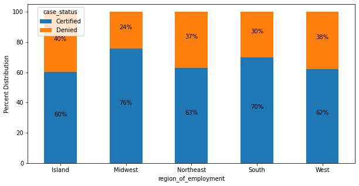

```python
stacked_barplot(data, "region_of_employment", "case_status")
```

**Observations**

- Companies in Midwest Region have highest Certification cases with 76%.
- Companies in Island region have the least Certification cases with 60%.

### unit_of_wage vs case_status

| case_status unit_of_wage | Certified | Denied |
| --- | --- | --- |
| Hour | 34.695773 | 65.304227 |
| Month | 61.797753 | 38.202247 |
| Week | 62.132353 | 37.867647 |
| Year | 69.899272 | 30.100728 |

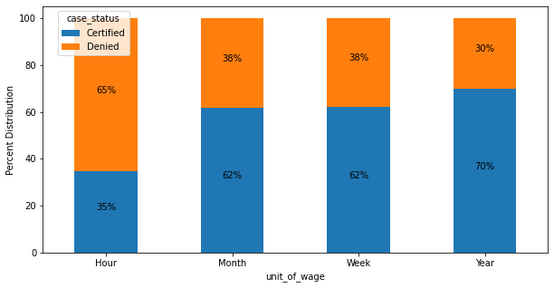

```python
stacked_barplot(data, "unit_of_wage", "case_status")
```

**Observations**

- Employees who are paid by hour have only 35% Certification cases.
- Employees paid by year have 70% Certification cases.

### full_time_position vs case_status

| case_status full_time_position | Certified | Denied |
| --- | --- | --- |
| N | 68.551367 | 31.448633 |
| Y | 66.602172 | 33.397828 |

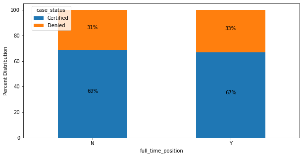

```python
stacked_barplot(data, "full_time_position", "case_status")
```

**Observations**

- If the employment is a Full time position does not seem to have much impact on the Visa Certification.

## Data Preprocessing (contd.)

### Converting Categorical Variables to Integer Data Types.

```python
replaceStruct = {
    "unit_of_wage": {"Year": 1, "Hour": 2080, "Week": 52, "Month": 12},
    "case_status": {"Denied": 0, "Certified": 1},
    "education_of_employee": {
        "High School": 1,
        "Bachelor's": 2,
        "Master's": 3,
        "Doctorate": 4,
    },
    "has_job_experience": {"N": 0, "Y": 1},
    "requires_job_training": {"N": 0, "Y": 1},
    "full_time_position": {"N": 0, "Y": 1},
}
```

```python
data = data.replace(replaceStruct)
```

- unit_of_wage is replaced with numerical values equivalent to workdays in a year.
- 1 year = 12 months = 2080 work hours = 52 weeks

### Converting prevaling_wage into a single unit "years" by addding a new column prevailing_wage_years

```python
data["prevailing_wage_years"] = data["prevailing_wage"] * data["unit_of_wage"]
```

```python
data.head()
```

|  | continent | education_of_employee | has_job_experience | requires_job_training | no_of_employees | yr_of_estab | region_of_employment | prevailing_wage | unit_of_wage | full_time_position | case_status | prevailing_wage_years |
| --- | --- | --- | --- | --- | --- | --- | --- | --- | --- | --- | --- | --- |
| 0 | Asia | 1 | 0 | 0 | 14513 | 2007 | West | 592.2029 | 2080 | 1 | 0 | 1231782.032 |
| 1 | Asia | 3 | 1 | 0 | 2412 | 2002 | Northeast | 83425.6500 | 1 | 1 | 1 | 83425.650 |
| 2 | Asia | 2 | 0 | 1 | 44444 | 2008 | West | 122996.8600 | 1 | 1 | 0 | 122996.860 |
| 3 | Asia | 2 | 0 | 0 | 98 | 1897 | West | 83434.0300 | 1 | 1 | 0 | 83434.030 |
| 4 | Africa | 3 | 1 | 0 | 1082 | 2005 | South | 149907.3900 | 1 | 1 | 1 | 149907.390 |

## Outlier Detection

**We have three numerical variable that are continous in nature : no_of_employees, yr_of_estab and prevailing_wage_years**

**Lets Detect their Outliers and Remove them**

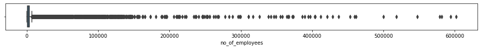

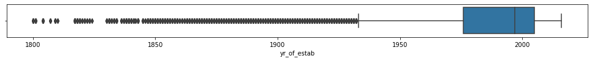

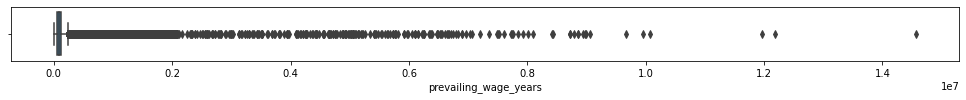

```python
# let's plot the boxplots of these columns to check for outliers
plt.figure(figsize=(17, 1))
sns.boxplot(data=data, x="no_of_employees")

# let's plot the boxplots of these columns to check for outliers
plt.figure(figsize=(17, 1))
sns.boxplot(data=data, x="yr_of_estab")

# let's plot the boxplots of these columns to check for outliers
plt.figure(figsize=(17, 1))
sns.boxplot(data=data, x="prevailing_wage_years")
```

- 75% of the number of employess are below 3505. There are huge number of outliers to the right, the max value being 602069. This data seems credible as there are companies with employees upto 602069.
- The yr_of_estab varies from 1800 to 2016. The mean is 1979 and median is 1997. Since mean is less than median data is skewed towards the left. The data seems credible as there can be companies established as early as 1800s.
- Lets see the below information for prevailing_wage_years

```python
data["prevailing_wage_years"].describe()
```

```
count    2.544700e+04
mean     1.974633e+05
std      5.788930e+05
min      1.000000e+02
25%      4.713751e+04
50%      8.283840e+04
75%      1.248266e+05
max      1.456915e+07
Name: prevailing_wage_years, dtype: float64
```

- 75% of yearly wages are below 124826.
- The max yearly wage is 14,569,150 which is too high to seem reasonable.
- Lets remove the outliers for prevailing_wage_years.

## Outlier Treatment

```python
def treat_outliers(df, col):
    """
    treats outliers in a variable
    col: str, name of the numerical variable
    df: dataframe
    col: name of the column
    """
    Q1 = df[col].quantile(0.25)  # 25th quantile
    Q3 = df[col].quantile(0.75)  # 75th quantile
    IQR = Q3 - Q1
    Lower_Whisker = Q1 - 1.5 * IQR
    Upper_Whisker = Q3 + 1.5 * IQR

    # all the values smaller than Lower_Whisker will be assigned the value of Lower_Whisker
    # all the values greater than Upper_Whisker will be assigned the value of Upper_Whisker
    df[col] = np.clip(df[col], Lower_Whisker, Upper_Whisker)

    return df


def treat_outliers_all(df, col_list):
    """
    treat outlier in all numerical variables
    col_list: list of numerical variables
    df: data frame
    """
    for c in col_list:
        df = treat_outliers(df, c)

    return df
```

```python
# treating the outliers
numerical_col = ["prevailing_wage_years"]
data = treat_outliers_all(data, numerical_col)
```

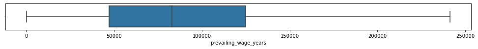

```python
# let's plot the boxplots of these columns after outlier treatment
sns.boxplot(data=data, x="prevailing_wage_years")
```

## Building bagging and boosting models

### Data Preparation for Modeling

**Dropping unwanted columns**

```python
data.drop(["prevailing_wage"], axis=1, inplace=True)
```

**Creating dummy varibles**

```python
dummy_data = pd.get_dummies(
    data, columns=["continent", "region_of_employment",], drop_first=True,
)
dummy_data.head()
```

|  | education_of_employee | has_job_experience | requires_job_training | no_of_employees | yr_of_estab | unit_of_wage | full_time_position | case_status | prevailing_wage_years | continent_Asia | continent_Europe | continent_North America | continent_Oceania | continent_South America | region_of_employment_Midwest | region_of_employment_Northeast | region_of_employment_South | region_of_employment_West |
| --- | --- | --- | --- | --- | --- | --- | --- | --- | --- | --- | --- | --- | --- | --- | --- | --- | --- | --- |
| 0 | 1 | 0 | 0 | 14513 | 2007 | 2080 | 1 | 0 | 241360.3175 | 1 | 0 | 0 | 0 | 0 | 0 | 0 | 0 | 1 |
| 1 | 3 | 1 | 0 | 2412 | 2002 | 1 | 1 | 1 | 83425.6500 | 1 | 0 | 0 | 0 | 0 | 0 | 1 | 0 | 0 |
| 2 | 2 | 0 | 1 | 44444 | 2008 | 1 | 1 | 0 | 122996.8600 | 1 | 0 | 0 | 0 | 0 | 0 | 0 | 0 | 1 |
| 3 | 2 | 0 | 0 | 98 | 1897 | 1 | 1 | 0 | 83434.0300 | 1 | 0 | 0 | 0 | 0 | 0 | 0 | 0 | 1 |
| 4 | 3 | 1 | 0 | 1082 | 2005 | 1 | 1 | 1 | 149907.3900 | 0 | 0 | 0 | 0 | 0 | 0 | 0 | 1 | 0 |

### Split Data

```python
X = dummy_data.drop("case_status", axis=1)  # Features
y = dummy_data["case_status"]  # Labels (Target Variable)
```

```python
# Splitting data into training and test set:
X_train, X_test, y_train, y_test = train_test_split(
    X, y, test_size=0.3, random_state=1, stratify=y
)
print(X_train.shape, X_test.shape)
```

```
(17812, 17) (7635, 17)
```

**The Stratify arguments maintain the original distribution of classes in the target variable while splitting the data into train and test sets.**

```python
print("Number of rows in train data =", X_train.shape[0])
print("Number of rows in test data =", X_test.shape[0])
print("Percentage of classes in training set:")
print(y_train.value_counts(normalize=True))
print("Percentage of classes in test set:")
print(y_test.value_counts(normalize=True))
```

```
Number of rows in train data = 17812
Number of rows in test data = 7635
Percentage of classes in training set:
1    0.668089
0    0.331911
Name: case_status, dtype: float64
Percentage of classes in test set:
1    0.668107
0    0.331893
Name: case_status, dtype: float64
```

## Model evaluation criterion

### Model can make wrong predictions as:

1. Predicting an employee will not get Visa Certification and the employee gets Visa Certification.
2. Predicting an employee will get Visa Certification and the employee does not get Visa Certification.

### Which case is more important?

- Predicting that employee will get Visa Certification and the employee does not get Visa Certification, i.e. losing on a valuable employee or asset.

### How to reduce this loss i.e need to reduce False Positives?

- Company wants Precision to be maximized, greater the Precision higher the chances of minimizing false positives. Hence, the focus should be on increasing Precision or minimizing the false positives so that the company get hard-working, talented, and qualified individuals both locally as well as abroad.

**Let's define a function to provide metric scores on the train and test set and a function to show confusion matrix so that we do not have to use the same code repetitively while evaluating models.**

```python
# defining a function to compute different metrics to check performance of a classification model built using sklearn
def model_performance_classification_sklearn(model, predictors, target):
    """
    Function to compute different metrics to check classification model performance

    model: classifier
    predictors: independent variables
    target: dependent variable
    """

    # predicting using the independent variables
    pred = model.predict(predictors)

    acc = accuracy_score(target, pred)  # to compute Accuracy
    recall = recall_score(target, pred)  # to compute Recall
    precision = precision_score(target, pred)  # to compute Precision
    f1 = f1_score(target, pred)  # to compute F1-score

    # creating a dataframe of metrics
    df_perf = pd.DataFrame(
        {"Accuracy": acc, "Recall": recall, "Precision": precision, "F1": f1,},
        index=[0],
    )

    return df_perf
```

```python
def confusion_matrix_sklearn(model, predictors, target):
    """
    To plot the confusion_matrix with percentages

    model: classifier
    predictors: independent variables
    target: dependent variable
    """
    y_pred = model.predict(predictors)
    cm = confusion_matrix(target, y_pred)
    labels = np.asarray(
        [
            ["{0:0.0f}".format(item) + "\n{0:.2%}".format(item / cm.flatten().sum())]
            for item in cm.flatten()
        ]
    ).reshape(2, 2)

    plt.figure(figsize=(6, 4))
    sns.heatmap(cm, annot=labels, fmt="")
    plt.ylabel("True label")
    plt.xlabel("Predicted label")
```

## Decision Tree Classifier

```
Training performance:
    Accuracy  Recall  Precision   F1
0       1.0     1.0        1.0  1.0
Testing performance:
    Accuracy    Recall  Precision        F1
0  0.656843  0.739071   0.745207  0.742126
```

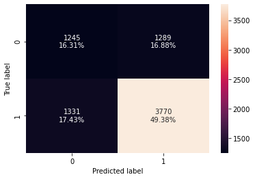

```python
# Fitting the model
d_tree = DecisionTreeClassifier(random_state=1)
d_tree.fit(X_train, y_train)

# Calculating different metrics
dtree_model_train_perf = model_performance_classification_sklearn(
    d_tree, X_train, y_train
)
print("Training performance:\n", dtree_model_train_perf)
dtree_model_test_perf = model_performance_classification_sklearn(d_tree, X_test, y_test)
print("Testing performance:\n", dtree_model_test_perf)
# Creating confusion matrix
confusion_matrix_sklearn(d_tree, X_test, y_test)
```

- The decision tree is overfitting the training data.

## Random Forest

```
Training performance:
    Accuracy  Recall  Precision        F1
0  0.999888     1.0   0.999832  0.999916
Testing performance:
    Accuracy    Recall  Precision        F1
0  0.724558  0.837287   0.770382  0.802442
```

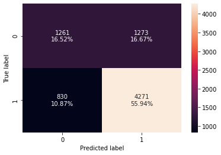

```python
# Fitting the model
rf_estimator = RandomForestClassifier(random_state=1)
rf_estimator.fit(X_train, y_train)

# Calculating different metrics
rf_estimator_model_train_perf = model_performance_classification_sklearn(
    rf_estimator, X_train, y_train
)
print("Training performance:\n", rf_estimator_model_train_perf)
rf_estimator_model_test_perf = model_performance_classification_sklearn(
    rf_estimator, X_test, y_test
)
print("Testing performance:\n", rf_estimator_model_test_perf)

# Creating confusion matrix
confusion_matrix_sklearn(rf_estimator, X_test, y_test)
```

- For Random Forest also the training data is overfitting.
- The Test Precision has increased compared to Decision tree.

## Bagging Classifier

```
Training performance:
    Accuracy   Recall  Precision        F1
0  0.984729  0.98605   0.991047  0.988543
Testing performance:
    Accuracy    Recall  Precision        F1
0  0.705043  0.782592    0.77741  0.779992
```

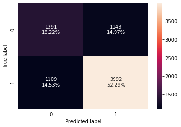

```python
# Fitting the model
bagging_classifier = BaggingClassifier(random_state=1)
bagging_classifier.fit(X_train, y_train)

# Calculating different metrics
bagging_classifier_model_train_perf = model_performance_classification_sklearn(
    bagging_classifier, X_train, y_train
)
print("Training performance:\n", bagging_classifier_model_train_perf)
bagging_classifier_model_test_perf = model_performance_classification_sklearn(
    bagging_classifier, X_test, y_test
)
print("Testing performance:\n", bagging_classifier_model_test_perf)
# Creating confusion matrix
confusion_matrix_sklearn(bagging_classifier, X_test, y_test)
```

- For Bagging Classifier also we can see that the training data is overfitting
- The Test Precision is similar compared to Random Forest..

## Tuning Decision Tree

```python
# Choose the type of classifier.
dtree_estimator = DecisionTreeClassifier(
    class_weight={0: 0.35, 1: 0.65}, random_state=1
)

# Grid of parameters to choose from
parameters = {
    "max_depth": np.arange(2, 10),
    "min_samples_leaf": [5, 7, 10, 15],
    "max_leaf_nodes": [2, 3, 5, 10, 15],
    "min_impurity_decrease": [0.0001, 0.001, 0.01, 0.1],
}

# Type of scoring used to compare parameter combinations
scorer = metrics.make_scorer(metrics.recall_score)

# Run the grid search
grid_obj = GridSearchCV(dtree_estimator, parameters, scoring=scorer, n_jobs=-1)
grid_obj = grid_obj.fit(X_train, y_train)

# Set the clf to the best combination of parameters
dtree_estimator = grid_obj.best_estimator_

# Fit the best algorithm to the data.
dtree_estimator.fit(X_train, y_train)
```

```
DecisionTreeClassifier(class_weight={0: 0.35, 1: 0.65}, max_depth=2,
                       max_leaf_nodes=2, min_impurity_decrease=0.1,
                       min_samples_leaf=5, random_state=1)
```

```python
# Calculating different metrics
dtree_estimator_model_train_perf = model_performance_classification_sklearn(
    dtree_estimator, X_train, y_train
)
print("Training performance:\n", dtree_estimator_model_train_perf)
dtree_estimator_model_test_perf = model_performance_classification_sklearn(
    dtree_estimator, X_test, y_test
)
print("Testing performance:\n", dtree_estimator_model_test_perf)
# Creating confusion matrix
confusion_matrix_sklearn(dtree_estimator, X_test, y_test)
```

```
Training performance:
    Accuracy  Recall  Precision        F1
0  0.668089     1.0   0.668089  0.801023
Testing performance:
    Accuracy  Recall  Precision        F1
0  0.668107     1.0   0.668107  0.801036
```

- Overfiiting of the Decion tree has reduced.
- There is generalized performance on training and testing data.
- Precision value has reduced.

## Tuning Random Forest

```python
# Choose the type of classifier.
rf_tuned = RandomForestClassifier(class_weight={0: 0.35, 1: 0.65}, random_state=1)

parameters = {
    "max_depth": list(np.arange(3, 5, 1)),
    "max_features": ["auto"],
    "max_samples": np.arange(0.7, 1.1, 0.1),
    "min_samples_split": np.arange(2, 20, 5),
    "n_estimators": np.arange(30, 100, 20),
    "min_impurity_decrease": [0.0001, 0.001, 0.01, 0.1],
}


# Type of scoring used to compare parameter combinations
scorer = metrics.make_scorer(metrics.recall_score)

# Run the grid search
grid_obj = GridSearchCV(rf_tuned, parameters, scoring=scorer, cv=5, n_jobs=-1)
grid_obj = grid_obj.fit(X_train, y_train)

# Set the clf to the best combination of parameters
rf_tuned = grid_obj.best_estimator_

# Fit the best algorithm to the data.
rf_tuned.fit(X_train, y_train)
```

```
RandomForestClassifier(class_weight={0: 0.35, 1: 0.65}, max_depth=3,
                       max_samples=0.7, min_impurity_decrease=0.001,
                       n_estimators=30, random_state=1)
```

```python
# Calculating different metrics
rf_tuned_model_train_perf = model_performance_classification_sklearn(
    rf_tuned, X_train, y_train
)
print("Training performance:\n", rf_tuned_model_train_perf)
rf_tuned_model_test_perf = model_performance_classification_sklearn(
    rf_tuned, X_test, y_test
)
print("Testing performance:\n", rf_tuned_model_test_perf)

# Creating confusion matrix
confusion_matrix_sklearn(rf_tuned, X_test, y_test)
```

```
Training performance:
    Accuracy  Recall  Precision        F1
0  0.668089     1.0   0.668089  0.801023
Testing performance:
    Accuracy  Recall  Precision        F1
0  0.668107     1.0   0.668107  0.801036
```

- Overfiiting of the Random Forest has reduced.
- There is generalized performance on training and testing data.
- Precision value has reduced.

## Tuning Bagging Classifier

```python
# Choose the type of classifier.
bagging_estimator_tuned = BaggingClassifier(random_state=1)

# Grid of parameters to choose from
parameters = {
    "max_samples": [0.7, 0.8, 0.9, 1],
    "max_features": [0.7, 0.8, 0.9, 1],
    "n_estimators": [10, 20, 30, 40, 50],
}

# Type of scoring used to compare parameter combinations
acc_scorer = metrics.make_scorer(metrics.recall_score)

# Run the grid search
grid_obj = GridSearchCV(bagging_estimator_tuned, parameters, scoring=acc_scorer, cv=5)
grid_obj = grid_obj.fit(X_train, y_train)

# Set the clf to the best combination of parameters
bagging_estimator_tuned = grid_obj.best_estimator_

# Fit the best algorithm to the data.
bagging_estimator_tuned.fit(X_train, y_train)
```

```
BaggingClassifier(max_features=0.7, max_samples=1, random_state=1)
```

```python
# Calculating different metrics
bagging_estimator_tuned_model_train_perf = model_performance_classification_sklearn(
    bagging_estimator_tuned, X_train, y_train
)
print("Training performance:\n", bagging_estimator_tuned_model_train_perf)
bagging_estimator_tuned_model_test_perf = model_performance_classification_sklearn(
    bagging_estimator_tuned, X_test, y_test
)
print("Testing performance:\n", bagging_estimator_tuned_model_test_perf)

# Creating confusion matrix
confusion_matrix_sklearn(bagging_estimator_tuned, X_test, y_test)
```

```
Training performance:
    Accuracy  Recall  Precision        F1
0  0.668089     1.0   0.668089  0.801023
Testing performance:
    Accuracy  Recall  Precision        F1
0  0.668107     1.0   0.668107  0.801036
```

- Overfiiting of the Bagging Classifier has reduced.
- There is generalized performance on training and testing data.
- Precision value has reduced.

## Comparing all the models

```python
# training performance comparison

models_train_comp_df = pd.concat(
    [
        dtree_model_train_perf.T,
        dtree_estimator_model_train_perf.T,
        rf_estimator_model_train_perf.T,
        rf_tuned_model_train_perf.T,
        bagging_classifier_model_train_perf.T,
        bagging_estimator_tuned_model_train_perf.T,
    ],
    axis=1,
)
models_train_comp_df.columns = [
    "Decision Tree",
    "Decision Tree Estimator",
    "Random Forest Estimator",
    "Random Forest Tuned",
    "Bagging Classifier",
    "Bagging Estimator Tuned",
]
print("Training performance comparison:")
models_train_comp_df
```

```
Training performance comparison:
```

|  | Decision Tree | Decision Tree Estimator | Random Forest Estimator | Random Forest Tuned | Bagging Classifier | Bagging Estimator Tuned |
| --- | --- | --- | --- | --- | --- | --- |
| Accuracy | 1.0 | 0.668089 | 0.999888 | 0.668089 | 0.984729 | 0.668089 |
| Recall | 1.0 | 1.000000 | 1.000000 | 1.000000 | 0.986050 | 1.000000 |
| Precision | 1.0 | 0.668089 | 0.999832 | 0.668089 | 0.991047 | 0.668089 |
| F1 | 1.0 | 0.801023 | 0.999916 | 0.801023 | 0.988543 | 0.801023 |

```python
# testing performance comparison

models_test_comp_df = pd.concat(
    [
        dtree_model_test_perf.T,
        dtree_estimator_model_test_perf.T,
        rf_estimator_model_test_perf.T,
        rf_tuned_model_test_perf.T,
        bagging_classifier_model_test_perf.T,
        bagging_estimator_tuned_model_test_perf.T,
    ],
    axis=1,
)
models_test_comp_df.columns = [
    "Decision Tree",
    "Decision Tree Estimator",
    "Random Forest Estimator",
    "Random Forest Tuned",
    "Bagging Classifier",
    "Bagging Estimator Tuned",
]
print("Testing performance comparison:")
models_test_comp_df
```

```
Testing performance comparison:
```

|  | Decision Tree | Decision Tree Estimator | Random Forest Estimator | Random Forest Tuned | Bagging Classifier | Bagging Estimator Tuned |
| --- | --- | --- | --- | --- | --- | --- |
| Accuracy | 0.656843 | 0.668107 | 0.724558 | 0.668107 | 0.705043 | 0.668107 |
| Recall | 0.739071 | 1.000000 | 0.837287 | 1.000000 | 0.782592 | 1.000000 |
| Precision | 0.745207 | 0.668107 | 0.770382 | 0.668107 | 0.777410 | 0.668107 |
| F1 | 0.742126 | 0.801036 | 0.802442 | 0.801036 | 0.779992 | 0.801036 |

- None of the models seem to be fully meeting all needed criteria.
- Precision values are high ~77 for Random Forest and Baaging Classifier but thier Train models are overfitting.
- Tuned Random Forest and Tuned Bagging Classifier have generalised Train and Test models. But their Precision value is less which is ~66.

### Feature importance of Tuned Random Forest

```python
feature_names = X_train.columns
```

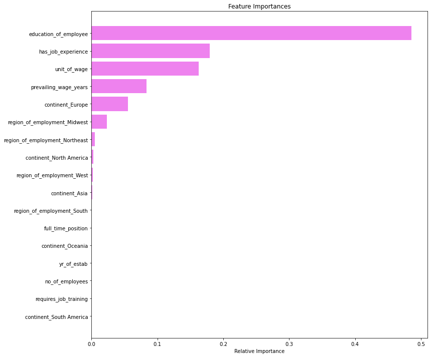

```python
importances = rf_tuned.feature_importances_
indices = np.argsort(importances)

plt.figure(figsize=(12, 12))
plt.title("Feature Importances")
plt.barh(range(len(indices)), importances[indices], color="violet", align="center")
plt.yticks(range(len(indices)), [feature_names[i] for i in indices])
plt.xlabel("Relative Importance")
plt.show()
```

- The three most important features to determine Visa Certification as per Tuned Random Forest model are -education_of_employee, has_job_experience and unit_of_wage

### Conclusion

- None of the models seem to be fully meeting all needed criteria.
- Precision values are high ~77 for Random Forest and Baaging Classifier but thier Train models are overfitting.
- Tuned Random Forest and Tuned Bagging Classifier have generalised Train and Test models. But their Precision value is less which is ~66.
- The three most important features to determine Visa Certification as per Tuned Random Forest model are -education_of_employee, has_job_experience and unit_of_wage

## AdaBoost Classifier

```
   Accuracy  Recall  Precision        F1
0  0.738715    0.89   0.759974  0.819864
   Accuracy    Recall  Precision        F1
0  0.733202  0.878651   0.759661  0.814835
```

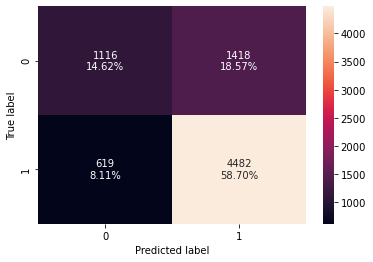

```python
# Fitting the model
ab_classifier = AdaBoostClassifier(random_state=1)
ab_classifier.fit(X_train, y_train)

# Calculating different metrics
ab_classifier_model_train_perf = model_performance_classification_sklearn(
    ab_classifier, X_train, y_train
)
print(ab_classifier_model_train_perf)
ab_classifier_model_test_perf = model_performance_classification_sklearn(
    ab_classifier, X_test, y_test
)
print(ab_classifier_model_test_perf)

# Creating confusion matrix
confusion_matrix_sklearn(ab_classifier, X_test, y_test)
```

- We are getting a generalized Test and Train model.
- Precion value is 75.9 for Test and Train data

## Gradient Boosting Classifier

```
Training performance:
    Accuracy    Recall  Precision        F1
0  0.755221  0.876555   0.782991  0.827135
Testing performance:
    Accuracy    Recall  Precision        F1
0    0.7463  0.865517   0.779209  0.820098
```

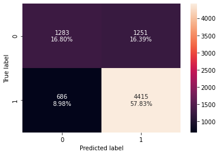

```python
# Fitting the model
gb_classifier = GradientBoostingClassifier(random_state=1)
gb_classifier.fit(X_train, y_train)

# Calculating different metrics
gb_classifier_model_train_perf = model_performance_classification_sklearn(
    gb_classifier, X_train, y_train
)
print("Training performance:\n", gb_classifier_model_train_perf)
gb_classifier_model_test_perf = model_performance_classification_sklearn(
    gb_classifier, X_test, y_test
)
print("Testing performance:\n", gb_classifier_model_test_perf)

# Creating confusion matrix
confusion_matrix_sklearn(gb_classifier, X_test, y_test)
```

- This is also a Generalized test and train model.
- The Preciosion value has increased ~ 78 compared to AdaBoost Classifier.